# Price Sensitivity, Seasonality, and Sales Performance Across Rainoil Retail Outlets: An Exploratory and Inferential Analysis of 2024–2025 Fuel Sales Data

## 6.3 PMS Price Trend Over Time

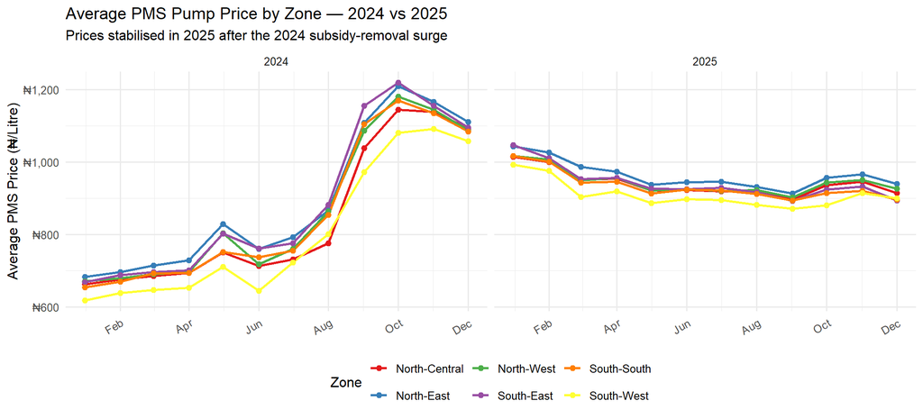

```r
stations_long |>
  filter(!is.na(pms_price)) |>
  group_by(month_date, zone, year) |>
  summarise(avg_price = mean(pms_price, na.rm = TRUE), .groups = "drop") |>
  ggplot(aes(x = month_date, y = avg_price, colour = zone, group = zone)) +
  geom_line(linewidth = 1) +
  geom_point(size = 2) +
  facet_wrap(~year, scales = "free_x") +
  scale_x_date(date_labels = "%b", date_breaks = "2 months") +
  scale_y_continuous(labels = label_comma(prefix = "₦")) +
  scale_colour_brewer(palette = "Set1") +
  labs(title = "Average PMS Pump Price by Zone — 2024 vs 2025",
       subtitle = "Prices stabilised in 2025 after the 2024 subsidy-removal surge",
       x = NULL, y = "Average PMS Price (₦/Litre)", colour = "Zone") +
  theme_minimal(base_size = 12) +
  theme(legend.position = "bottom",
        axis.text.x = element_text(angle = 30, hjust = 1))
```

## 6.4 Price vs. Volume Scatter

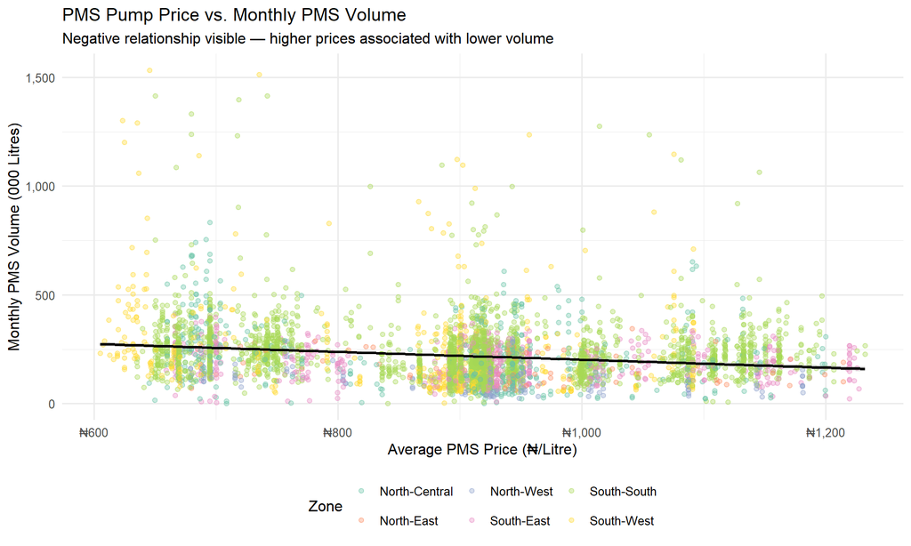

```r
stations_long |>
  filter(!is.na(pms_price), !is.na(pms_vol), pms_vol > 0) |>
  ggplot(aes(x = pms_price, y = pms_vol / 1000, colour = zone)) +
  geom_point(alpha = 0.35, size = 1.5) +
  geom_smooth(method = "lm", se = TRUE, colour = "black", linewidth = 0.9) +
  scale_y_continuous(labels = label_comma()) +
  scale_x_continuous(labels = label_comma(prefix = "₦")) +
  scale_colour_brewer(palette = "Set2") +
  labs(title = "PMS Pump Price vs. Monthly PMS Volume",
       subtitle = "Negative relationship visible — higher prices associated with lower volume",
       x = "Average PMS Price (₦/Litre)",
       y = "Monthly PMS Volume (000 Litres)",
       colour = "Zone") +
  theme_minimal(base_size = 12) +
  theme(legend.position = "bottom")
```

## 6.5 Network Heatmap — Station Performance by Month

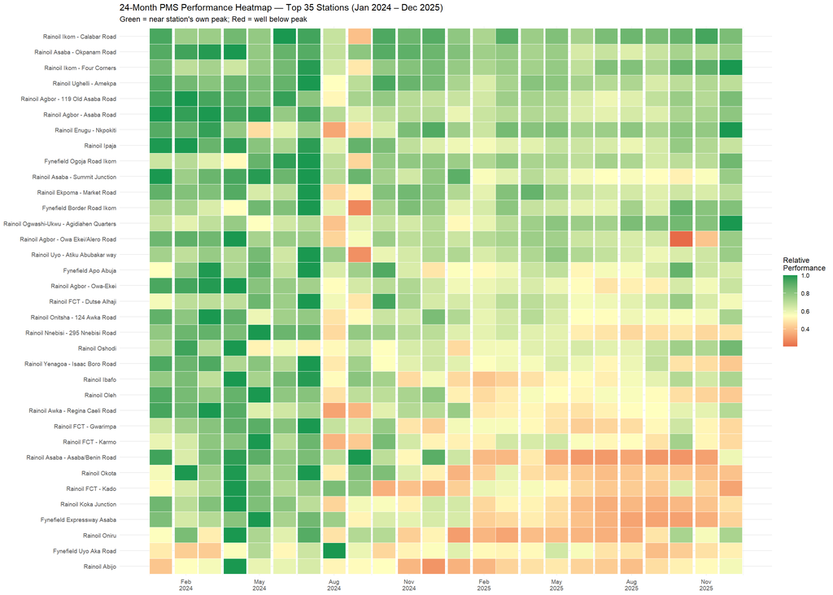

```r
# Normalise each station's monthly PMS to its own 24-month peak (0–1 scale)
heat_data <- stations_long |>
  filter(!is.na(pms_vol)) |>
  group_by(station_name) |>
  mutate(station_max = max(pms_vol, na.rm = TRUE)) |>
  ungroup() |>
  mutate(pms_norm = if_else(station_max > 0, pms_vol / station_max, 0)) |>
  semi_join(annual_pms_all |> slice_head(n = 35), by = "station_name")

heat_data |>
  ggplot(aes(x = month_date,
             y = reorder(station_name, pms_norm, FUN = mean),
             fill = pms_norm)) +
  geom_tile(colour = "white", linewidth = 0.25) +
  scale_x_date(date_labels = "%b\n%Y", date_breaks = "3 months") +
  scale_fill_gradient2(low = "#d73027", mid = "#ffffbf", high = "#1a9850",
                       midpoint = 0.55, name = "Relative\nPerformance") +
  labs(title = "24-Month PMS Performance Heatmap — Top 35 Stations (Jan 2024 – Dec 2025)",
       subtitle = "Green = near station's own peak; Red = well below peak",
       x = NULL, y = NULL) +
  theme_minimal(base_size = 9) +
  theme(axis.text.y = element_text(size = 7),
        legend.position = "right")
```

## 6.6 Seasonal Demand Pattern

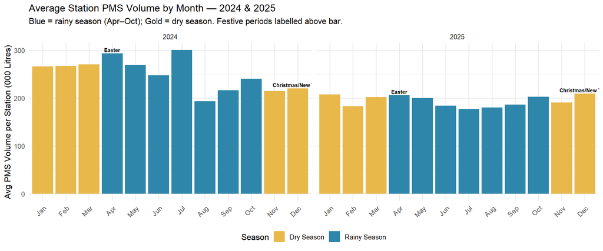

```r
stations_long |>
  filter(pms_vol > 0) |>
  group_by(month, season, festive, year) |>
  summarise(avg_pms = mean(pms_vol, na.rm = TRUE) / 1000, .groups = "drop") |>
  ggplot(aes(x = month, y = avg_pms, fill = season)) +
  geom_col() +
  geom_text(aes(label = if_else(festive != "Non-Festive", festive, "")),
            vjust = -0.4, size = 2.6, colour = "black", fontface = "bold") +
  facet_wrap(~year) +
  scale_fill_manual(values = c("Rainy Season" = "#2E86AB",
                               "Dry Season"   = "#E8B84B")) +
  scale_y_continuous(labels = label_comma()) +
  labs(title = "Average Station PMS Volume by Month — 2024 & 2025",
       subtitle = "Blue = rainy season (Apr–Oct); Gold = dry season. Festive periods labelled above bar.",
       x = NULL, y = "Avg PMS Volume per Station (000 Litres)",
       fill = "Season") +
  theme_minimal(base_size = 12) +
  theme(legend.position  = "bottom",
        axis.text.x      = element_text(angle = 45, hjust = 1))
```

# 7 Technique 3 — Hypothesis Testing

**Theory recap:** Hypothesis testing provides a formal framework for deciding whether observed differences in data could plausibly arise by chance (Adi, 2026, Ch. 6). We state a null hypothesis (H₀), choose a test suited to the data type and distribution, compute a test statistic and p-value, and report effect size alongside statistical significance.

**Business justification:** When the MD or Head of Retail Sales asks “Do stations in the South-West genuinely out-sell those in the North, or is the difference noise?” — a formal test is the evidence-based answer. Three hypotheses are tested: one on regional differences (ANOVA), one on year-on-year volume change (paired t-test), and one on seasonal demand periods (ANOVA) — directly addressing whether rain season and festive periods drive retail sales volumes independently of price.

## 7.1 Hypothesis 1 — Do mean monthly PMS volumes differ across zones? (One-Way ANOVA)

**H₀:** Mean monthly PMS volume is the same across all geopolitical zones.  
**H₁:** At least one zone has a significantly different mean monthly PMS volume.

**Assumption checks:**

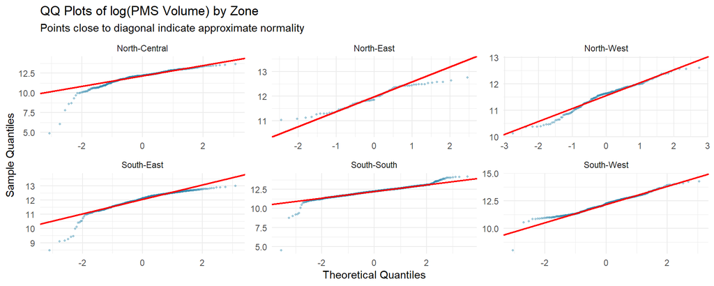

```r
# Check normality by zone — QQ plots on log-transformed volume
stations_long |>
  filter(!is.na(pms_vol), pms_vol > 0) |>
  ggplot(aes(sample = log1p(pms_vol))) +
  stat_qq(alpha = 0.4, size = 0.8, colour = "#2E86AB") +
  stat_qq_line(colour = "red", linewidth = 0.8) +
  facet_wrap(~zone, scales = "free") +
  labs(title = "QQ Plots of log(PMS Volume) by Zone",
       subtitle = "Points close to diagonal indicate approximate normality",
       x = "Theoretical Quantiles", y = "Sample Quantiles") +
  theme_minimal(base_size = 11)
```

```r
# Levene's test for homogeneity of variance
levene_result <- leveneTest(
  log1p(pms_vol) ~ zone,
  data = stations_long |> filter(!is.na(pms_vol), pms_vol > 0)
)
print(levene_result)
```

```
Levene's Test for Homogeneity of Variance (center = median)
        Df F value    Pr(>F)
group    5  52.341 < 2.2e-16 ***
      4290
---
Signif. codes:  0 '***' 0.001 '**' 0.01 '*' 0.05 '.' 0.1 ' ' 1
```

```r
# One-way ANOVA on log-transformed volume
anova_data <- stations_long |>
  filter(!is.na(pms_vol), pms_vol > 0)

anova_model <- aov(log1p(pms_vol) ~ zone, data = anova_data)
anova_summary <- summary(anova_model)
print(anova_summary)
```

```
              Df Sum Sq Mean Sq F value Pr(>F)
zone           5   94.1   18.83   52.24 <2e-16 ***
Residuals   4290 1545.9    0.36
---
Signif. codes:  0 '***' 0.001 '**' 0.01 '*' 0.05 '.' 0.1 ' ' 1
```

```r
# Effect size — Eta-squared
ss_between <- anova_summary[[1]]["zone", "Sum Sq"]
ss_total   <- sum(anova_summary[[1]][, "Sum Sq"])
eta_sq     <- ss_between / ss_total
cat("\nEta-squared (effect size):", round(eta_sq, 4), "\n")
```

```
Eta-squared (effect size): 0.0574
```

```r
cat("Interpretation:", case_when(
  eta_sq < 0.01 ~ "Negligible",
  eta_sq < 0.06 ~ "Small",
  eta_sq < 0.14 ~ "Medium",
  TRUE ~ "Large"
))
```

```
Interpretation: Small
```

```r
# Post-hoc Tukey HSD
tukey_result <- TukeyHSD(anova_model, "zone")
tukey_df <- as.data.frame(tukey_result$zone) |>
  rownames_to_column("Comparison") |>
  rename(Difference = diff, Lower = lwr, Upper = upr, `p (adjusted)` = `p adj`) |>
  mutate(Significant = if_else(`p (adjusted)` < 0.05, "Yes", "No"))

tukey_df |>
  kable(digits = 4, caption = "Tukey HSD Post-Hoc Comparisons") |>
  kable_styling(bootstrap_options = c("striped","hover")) |>
  row_spec(which(tukey_df$Significant == "Yes"), background = "#d4edda")
```

Tukey HSD Post-Hoc Comparisons

| Comparison | Difference | Lower | Upper | p (adjusted) | Significant |
| --- | --- | --- | --- | --- | --- |
| North-East-North-Central | -0.1242 | -0.3425 | 0.0941 | 0.5836 | No |
| North-West-North-Central | -0.5230 | -0.6773 | -0.3687 | 0.0000 | Yes |
| South-East-North-Central | -0.0563 | -0.1658 | 0.0532 | 0.6864 | No |
| South-South-North-Central | 0.1586 | 0.0721 | 0.2452 | 0.0000 | Yes |
| South-West-North-Central | 0.1307 | 0.0161 | 0.2454 | 0.0147 | Yes |
| North-West-North-East | -0.3988 | -0.6410 | -0.1565 | 0.0000 | Yes |
| South-East-North-East | 0.0679 | -0.1486 | 0.2844 | 0.9480 | No |
| South-South-North-East | 0.2828 | 0.0770 | 0.4887 | 0.0013 | Yes |
| South-West-North-East | 0.2549 | 0.0358 | 0.4741 | 0.0118 | Yes |
| South-East-North-West | 0.4667 | 0.3149 | 0.6185 | 0.0000 | Yes |
| South-South-North-West | 0.6816 | 0.5455 | 0.8178 | 0.0000 | Yes |
| South-West-North-West | 0.6537 | 0.4982 | 0.8093 | 0.0000 | Yes |
| South-South-South-East | 0.2149 | 0.1330 | 0.2969 | 0.0000 | Yes |
| South-West-South-East | 0.1870 | 0.0758 | 0.2983 | 0.0000 | Yes |
| South-West-South-South | -0.0279 | -0.1166 | 0.0608 | 0.9475 | No |